# 8.1 Predict

TG

2019-06-06

```r
load("biomass_model_list.Rdata")
load("fishermen_model_list.Rdata")
load("number_of_fishing_days.Rdata")
load("max_km.Rdata")
```

```r
library("dplyr")
library("tidyr")
library("ggmap")
library("ggplot2")
library("maps")
library("geosphere")
library("suncalc")
library("mgcv")
library("MuMIn")
library("lubridate")
```

### biomass model (7)

- years fishing- continues, “cr” smoother
- time_fishing_hours - continues (limited to 8 hours), “ad” smoother
- month - continues, “cc” smoother
- site - random

```r
biomass_model<-biomass_list_5.4[[3]]
summary(biomass_model)
```

```
##
## Family: Tweedie(1.5)
## Link function: log
##
## Formula:
## tot_biomass ~ s(time_fishing_hours, bs = "ad") + s(month, bs = "cc",
##     k = 12) + s(years_fishing, bs = "cr") + s(site, bs = "re")
##
## Parametric coefficients:
##             Estimate Std. Error t value Pr(>|t|)
## (Intercept)  -2.6159     0.1386  -18.87   <2e-16 ***
## ---
## Signif. codes:  0 '***' 0.001 '**' 0.01 '*' 0.05 '.' 0.1 ' ' 1
##
## Approximate significance of smooth terms:
##                          edf Ref.df      F  p-value
## s(time_fishing_hours)  6.294  7.750 17.932  < 2e-16 ***
## s(month)               3.429 10.000  3.529 1.87e-05 ***
## s(years_fishing)       2.873  3.582  6.237 0.000155 ***
## s(site)               23.244 42.000  0.953 0.004150 **
## ---
## Signif. codes:  0 '***' 0.001 '**' 0.01 '*' 0.05 '.' 0.1 ' ' 1
##
## R-sq.(adj) =  0.139   Deviance explained = 30.9%
## -REML =  534.3  Scale est. = 1.612     n = 1034
```

### fishermen model

- month - smoother…
- site - factor, random
- day_of_the_week (weekday/weekend) - factor,fixed

```r
fishermen_model<-fishermen.list[[8]]
summary(fishermen_model)
```

```
##
## Family: Negative Binomial(1.736)
## Link function: log
##
## Formula:
## fix_fisher_km ~ s(month, bs = "cc", k = 12) + s(site, bs = "re") +
##     day_of_the_week
##
## Parametric coefficients:
##                         Estimate Std. Error z value Pr(>|z|)
## (Intercept)               1.0797     0.1463   7.382 1.55e-13 ***
## day_of_the_weekweek_end   0.6565     0.1192   5.506 3.67e-08 ***
## ---
## Signif. codes:  0 '***' 0.001 '**' 0.01 '*' 0.05 '.' 0.1 ' ' 1
##
## Approximate significance of smooth terms:
##             edf Ref.df Chi.sq  p-value
## s(month)  3.792     10  28.27 0.000508 ***
## s(site)  31.818     42 163.68  < 2e-16 ***
## ---
## Signif. codes:  0 '***' 0.001 '**' 0.01 '*' 0.05 '.' 0.1 ' ' 1
##
## R-sq.(adj) =  0.495   Deviance explained =   48%
## -REML = 735.27  Scale est. = 1         n = 274
```

# PREDICT!

## biomass predict

1. find a contents value of expirance (years fishing) to use for the predict
- later might try other

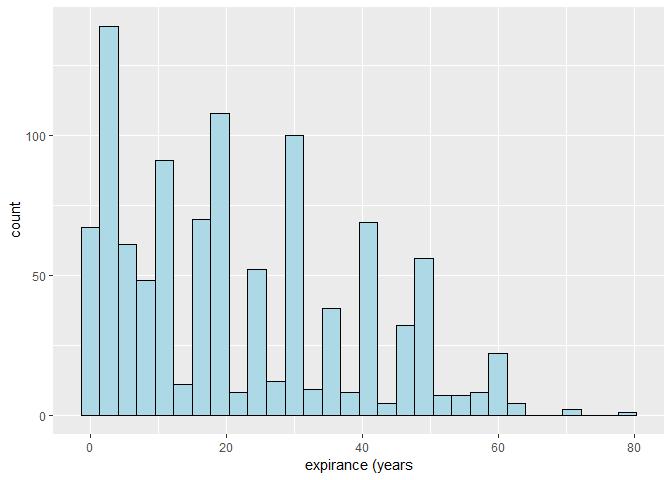

```r
ggplot(data = biomass_5.4, aes(x=years_fishing)) +
  geom_histogram(color="black", fill="lightblue")+ labs(x = "expirance (years")
```

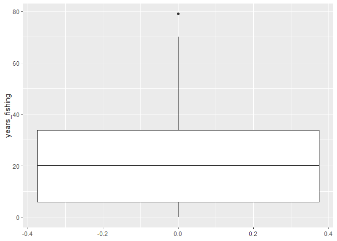

```r
ggplot(data = biomass_5.4,aes(y=years_fishing))+geom_boxplot()
```

```r
median(biomass_5.4$years_fishing)
```

```
## [1] 20
```

```r
mean(biomass_5.4$years_fishing)
```

```
## [1] 21.64137
```

Ill choose 20 as my predict default

```r
sites<-unique(biomass_5.4$site)

site_number<-43

#make sure both datas have exactly the same sites...

#unique((fishermen$site)) %in% unique(biomass_5.4$site)
```

This table predict the biomass per hour per fishermen to a representative day in each month in each site

```r
sample_biomss_data<-data.frame("month"=rep(1:12,site_number),
                                 "site"=rep(sites,each=12),
                                 "years_fishing"=rep(20),
                                 "time_fishing_hours"=rep(1))
```

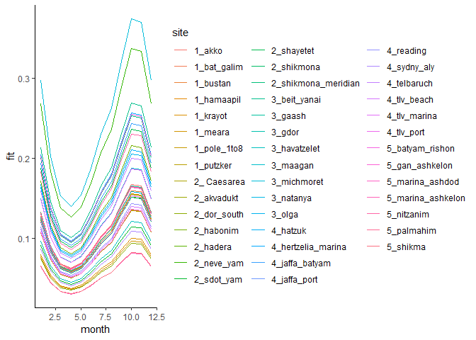

```r
predict_biomass<-predict.gam(biomass_model,sample_biomss_data,type="response",se.fit = T)

predicted_biomass_data<-data.frame()
predicted_biomass_data<-bind_cols(predict_biomass)

predicted_biomass_data<-cbind.data.frame(sample_biomss_data,predicted_biomass_data)

ggplot(data = predicted_biomass_data,aes(x=month,y=fit,color=site))+
  geom_line()+theme_classic()
```

## fishermen predict

here i need to predict table because of the weekday/weekend separation

1. predict table for **weekday**

```r
sample_fishermen_data_weekday<-data.frame("month"=rep(1:12,site_number),
                                 "site"=rep(sites,each=12),
                                 "day_of_the_week"=rep("week_day"))
```

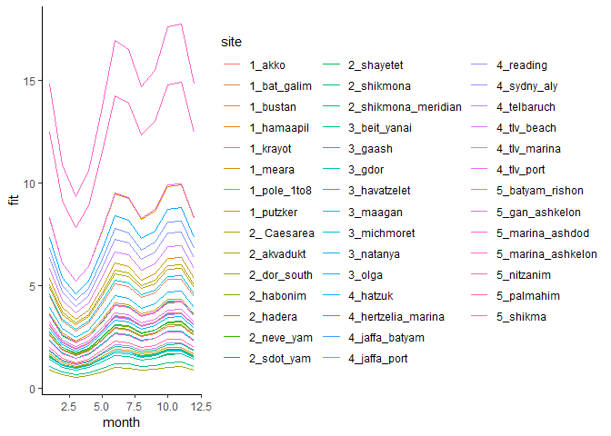

```r
predict_fishermen_weekday<-predict.gam(fishermen_model,sample_fishermen_data_weekday,type="response",se.fit = T)

predicted_fishermen_weekday_data<-data.frame()
predicted_fishermen_weekday_data<-bind_cols(predict_fishermen_weekday)

predicted_fishermen_weekday_data<-cbind.data.frame(sample_fishermen_data_weekday,predicted_fishermen_weekday_data)

ggplot(data = predicted_fishermen_weekday_data,aes(x=month,y=fit,color=site))+
  geom_line()+theme_classic()
```

2. predict table for **weekend**

```r
sample_fishermen_data_weekend<-data.frame("month"=rep(1:12,site_number),
                                 "site"=rep(sites,each=12),
                                 "day_of_the_week"=rep("week_end"))
```

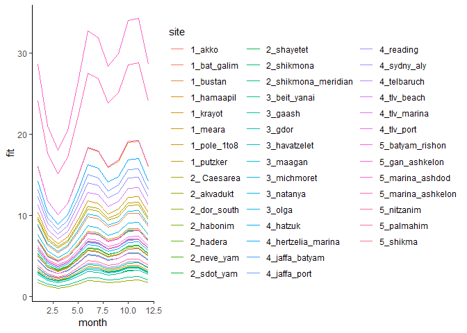

```r
predict_fishermen_weekend<-predict.gam(fishermen_model,sample_fishermen_data_weekend,type="response",se.fit = T)

predicted_fishermen_weekend_data<-data.frame()
predicted_fishermen_weekend_data<-bind_cols(predict_fishermen_weekend)

predicted_fishermen_weekend_data<-cbind.data.frame(sample_fishermen_data_weekend,predicted_fishermen_weekend_data)

ggplot(data = predicted_fishermen_weekend_data,aes(x=month,y=fit,color=site))+
  geom_line()+theme_classic()
```

# Combine the data frames!!

```r
combaine<-data.frame("month"=rep(1:12,site_number),
                                 "site"=rep(sites,each=12))

combaine<-combaine %>% slice(rep(1:n(), each = 2))
combaine$day_of_the_week<-rep(c("week_day","week_end"))
```

```r
pb<-select(predicted_biomass_data,month,site,fit)
colnames(pb)<-c("month","site","biomass_hour_fishermen")
```

```r
combaine<-left_join(combaine,pb,by=c("month","site"))
```

```r
p_fisher_wd<-select(predicted_fishermen_weekday_data,month,site,day_of_the_week,fit)
colnames(p_fisher_wd)<-c("month","site","day_of_the_week","number_of_fishermen_km")

p_fisher_we<-select(predicted_fishermen_weekend_data,month,site,day_of_the_week,fit)
colnames(p_fisher_we)<-c("month","site","day_of_the_week","number_of_fishermen_km")

p_fisher<-rbind(p_fisher_wd,p_fisher_we)

combaine<-left_join(combaine,p_fisher,by=c("month","site","day_of_the_week"))
```

number of fishing days

```r
combaine$fishing_days<-rep(c(13,4))
```

number of fishing hours

```r
combaine$fishing_hours<-rep(12)
```

add the km per site column

```r
colnames(max_km)<-c("site","site_km")

combaine<-left_join(combaine,max_km,by="site")
```

# add exstra km

create the template to the extra site

```r
exstara_site<-filter(combaine,site=="4_hertzelia_marina")
exstara_site$site<-rep("Exstra_site")
exstara_site$site_km<-rep(25)

exstara_site$biomass_hour_fishermen<-NULL
exstara_site$number_of_fishermen_km<-NULL
```

crate the monthly mean number of biomass and fishermen for sites that are not hot spots and add the biomass

```r
site_not_hs<-fishermen %>% select(site,hot_spot) %>% filter(!duplicated(site)) %>% filter(hot_spot=="no")

pb_not_hs<-pb %>% filter(site %in% site_not_hs$site) %>% group_by(month) %>% summarise("biomass_hour_fishermen"=mean(biomass_hour_fishermen))

exstara_site<-left_join(exstara_site,pb_not_hs,by="month")
```

add the fishermen

```r
fisher_not_hs_wday<-p_fisher_wd %>% filter(site %in% site_not_hs$site) %>% group_by(month,day_of_the_week) %>% summarise("number_of_fishermen_km"=mean(number_of_fishermen_km))

fisher_not_hs_wend<-p_fisher_we %>% filter(site %in% site_not_hs$site) %>% group_by(month,day_of_the_week) %>% summarise("number_of_fishermen_km"=mean(number_of_fishermen_km))

p_fisher_not_hs<-rbind(fisher_not_hs_wday,fisher_not_hs_wend)

exstara_site<-left_join(exstara_site,p_fisher_not_hs,by=c("month","day_of_the_week"))



exstara_site<-select(exstara_site,month,site,day_of_the_week,biomass_hour_fishermen,number_of_fishermen_km,fishing_days,fishing_hours,site_km)
```

add to the combine data

```r
combaine<-rbind(combaine,exstara_site)
```

multiply the biomass per fishermen per hour in the fishing hours (12) and the fishing days that way the new biomass will ce per month! (divided to week end and week day)

```r
combaine<-combaine %>% mutate("biomass_per_month"=biomass_hour_fishermen*fishing_hours*fishing_days)
```

multiply the number of fishermen per km per site to fishermen for site

```r
combaine<-combaine %>% mutate("fishermen_per_site"=number_of_fishermen_km*site_km)
```

multiply the biomass per month in the number of fishermen per site

```r
combaine<-combaine %>% mutate("biomass_per_site"=biomass_per_month*fishermen_per_site)
```

sum over all the year for all the coast!!!

```r
biomass_for_israel<-sum(combaine$biomass_per_site)
biomass_for_israel<-biomass_for_israel/1000
biomass_for_israel
```

```
## [1] 162.9818
```

sum only the extra site

```r
extra<-filter(combaine,site=="Exstra_site")
biomass_for_extra<-sum(extra$biomass_per_site)
biomass_for_extra<-biomass_for_extra/1000
biomass_for_extra
```

```
## [1] 25.95913
```